# Data Exploration and Preparation Final Exam

Student: 2022579 Mark Christian Albinto

Lecturer: Dr. Muhammad Iqbal

Date: 06 January 2023 10:00 - 07 January 2023 10:00

Clear all environment variables for new project

```r
rm(list = ls())
```

# Assessment Tasks

### Question 1

Create the table/dataframe for question 1 (Table 2.1)

```r
table_21_customer_id <- c(1001, 1002, 1003, 1004, 1005)
table_21_zip <- c(10048, 'J2S7K7', 90210, 6269, 55101)
table_21_gender <- c('M', 'F', NA, 'M', 'F')
table_21_income <- c(78000, -40000, 10000000, 50000, 99999)
table_21_age <- c('C', 40, 45, 0, 30)
table_21_marital_status <- c('M', 'W', 'S', 'S', 'D')
table_21_transaction_amount <- c(5000, 4000, 7000, 1000, 3000)

df_table_21 <- data.frame(table_21_customer_id, table_21_zip, table_21_gender, table_21_income, table_21_age, table_21_marital_status, table_21_transaction_amount)

table21_column_names <- c('Customer_ID', 'Zip', 'Gender', 'Income', 'Age', 'Marital_Status', 'Transaction_Amount')
colnames(df_table_21) <- table21_column_names

df_table_21
```

| Customer_ID | Zip | Gender | Income | Age | Marital_Status | Transaction_Amount |
| --- | --- | --- | --- | --- | --- | --- |
| 1001 | 10048 | M | 78000 | C | M | 5000 |
| 1002 | J2S7K7 | F | -40000 | 40 | W | 4000 |
| 1003 | 90210 | NA | 10000000 | 45 | S | 7000 |
| 1004 | 6269 | M | 50000 | 0 | S | 1000 |
| 1005 | 55101 | F | 99999 | 30 | D | 3000 |

Take a look at the structure of the dataframe

```r
str(df_table_21)
```

```
'data.frame':   5 obs. of  7 variables:
 $ Customer_ID       : num  1001 1002 1003 1004 1005
 $ Zip               : chr  "10048" "J2S7K7" "90210" "6269" ...
 $ Gender            : chr  "M" "F" NA "M" ...
 $ Income            : num  78000 -40000 10000000 50000 99999
 $ Age               : chr  "C" "40" "45" "0" ...
 $ Marital_Status    : chr  "M" "W" "S" "S" ...
 $ Transaction_Amount: num  5000 4000 7000 1000 3000
```

#### a) Refer to the income attribute of the five customers in Table 2.1, before pre-processing.

##### a:i) Find the mean income before pre-processing.

```r
table_21_income_mean <- mean(df_table_21$Income)

table_21_income_mean
```

```
[1] 2037600
```

##### a:ii) What does this number actually mean?

The value represents the “average” of the values in the dataset, but it may not be representative of the majority of the values. This is because the mean is sensitive to outliers, or values that are significantly higher or lower than the majority of the values in the dataset. In this case, the value of 10,000,000 is an outlier that is pulling the mean up significantly.

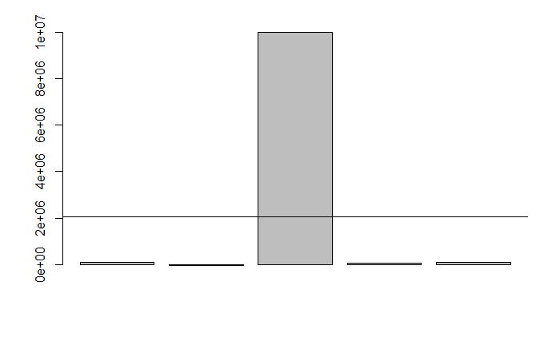

```r
barplot(df_table_21$Income)
abline(h = table_21_income_mean)
```

##### a:iii) Now, calculate the mean income for the three values left after pre-processing. Does this value have a meaning?

In the case of the values in Income, it is likely that the values -40000 and 10000000 are considered outliers because they are much smaller and much larger, respectively, than the other values in the list. These extreme values could potentially skew the results of statistical analyses, such as mean and median calculations, and may not be representative of the underlying data.

By removing these outliers, we can obtain a more accurate and representative view of the data.

```r
df_table_21_income_processed <- df_table_21$Income[c(1, 4, 5)]

df_table_21_income_processed_mean <- mean(df_table_21_income_processed)

df_table_21_income_processed_mean
```

```
[1] 75999.67
```

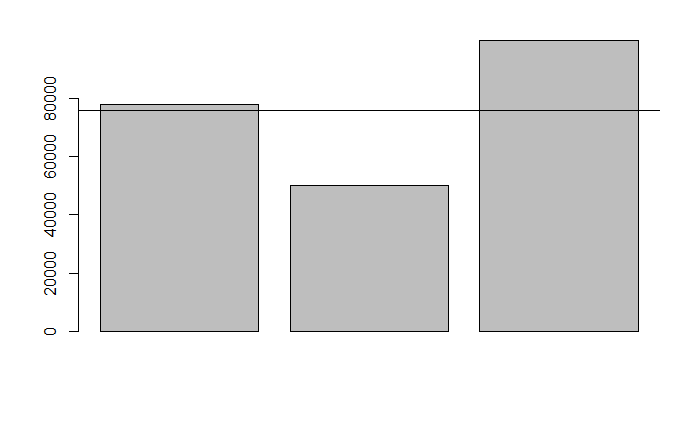

```r
barplot(df_table_21_income_processed)
abline(h = df_table_21_income_processed_mean)
```

The new mean does have value because it provides a new summary statistic for the data. However, it is important to consider how the removal of the outliers has affected the mean and whether or not the new mean is representative of the underlying data. Removing outliers can change the mean and may result in a different interpretation of the data. It is important to carefully consider whether or not to remove outliers, as they may contain important information and may not always be the result of measurement errors or other anomalies.

#### b) Explain why zip codes should be considered text variables rather than numeric.

Zip codes should be considered text variables rather than numeric variables because they do not have a natural ordering. For example, the zip code “90210” is not greater than or less than the zip code “10001”. Therefore, it doesn’t make sense to perform mathematical operations like addition or subtraction on zip codes.

In addition, zip codes may contain leading zeros, which can be lost when they are treated as numeric variables. For example, the zip code “00210” would be stored as 210 if it were treated as a numeric variable, but this would lose important information.

In general, it is a good idea to treat variables that represent categorical data, such as zip codes, as text variables rather than numeric variables. This will ensure that the data is stored and analyzed correctly.

Here are a few points to consider when deciding whether to treat zip codes as text or numeric variables:

- Zip codes are often used to identify geographic regions, such as cities, neighborhoods, or census tracts. They are not continuous variables like height or weight, which can take on any value within a certain range.
- Some zip codes contain letters, in addition to numbers. This would not be possible if zip codes were treated as numeric variables.
- Zip codes are often used as a key field in databases. This means that they are used to uniquely identify records in a table. It is generally easier to use text fields as keys, rather than numeric fields, because text fields can accommodate a wider range of values and are less prone to errors.

#### c) Identify which columns are suitable for the categorical datatypes in the Table 2.1 and provide the appropriate encoding scheme to replace the variables with numeric data.

The following columns are suitable for the categorical datatypes:

- ‘Customer ID’: This column represents a unique identifier for each customer, and the values are not ordered or continuous. Therefore, it is suitable for a categorical datatype.
- ‘Zip’: This column represents a zip code, which is a categorical variable because it does not have a natural ordering.
- ‘Gender’: This column represents a person’s gender (Male or Female), which is a categorical variable because it is not a continuous or ordered variable.
- ‘Marital Status’: This column represents a person’s marital status (Divorced, Married, Single, Widowed), which is a categorical variable because it is not a continuous or ordered variable.

To replace these variables with numeric data, we can use an encoding scheme such as one-hot encoding. One-hot encoding creates a new binary column for each category, with a value of 1 indicating that the row belongs to that category and a value of 0 indicating that it does not.

For example, to one-hot encode the ‘Gender’ column, we would create two new binary columns: ‘Gender_Male’ and ‘Gender_Female’. Each row would have a value of 1 in either the ‘Gender_Male’ column or the ‘Gender_Female’ column, depending on the person’s gender.

Here is a demonstration of One-hot Encoding the Gender and Marital Status column using dummyVars function from caret library

```r
# install.packages('caret')
library(caret)

df_table_21_one_hot_formula_gender <- dummyVars("~ Gender", data=df_table_21)

df_table_21_one_hot_gender <- data.frame(predict(df_table_21_one_hot_formula_gender, newdata = df_table_21))

df_table_21_one_hot_gender
```

|  | GenderF | GenderM |
| --- | --- | --- |
| 1 | 0 | 1 |
| 2 | 1 | 0 |
| 3 | NA | NA |
| 4 | 0 | 1 |
| 5 | 1 | 0 |

Combine encoded data to the dataframe

```r
df_table_21 <- cbind(df_table_21, df_table_21_one_hot_gender)

df_table_21
```

|  | Customer_ID | Zip | Gender | Income | Age | Marital_Status | Transaction_Amount | GenderF | GenderM |
| --- | --- | --- | --- | --- | --- | --- | --- | --- | --- |
| 1 | 1001 | 10048 | M | 78000 | C | M | 5000 | 0 | 1 |
| 2 | 1002 | J2S7K7 | F | -40000 | 40 | W | 4000 | 1 | 0 |
| 3 | 1003 | 90210 | NA | 10000000 | 45 | S | 7000 | NA | NA |
| 4 | 1004 | 6269 | M | 50000 | 0 | S | 1000 | 0 | 1 |
| 5 | 1005 | 55101 | F | 99999 | 30 | D | 3000 | 1 | 0 |

```r
df_table_21_one_hot_formula_marital_status <- dummyVars("~ Marital_Status", data=df_table_21)

df_table_21_one_hot_marital_status <- data.frame(predict(df_table_21_one_hot_formula_marital_status, newdata = df_table_21))

df_table_21_one_hot_marital_status
```

|  | Marital_StatusD | Marital_StatusM | Marital_StatusS | Marital_StatusW |
| --- | --- | --- | --- | --- |
| 1 | 0 | 1 | 0 | 0 |
| 2 | 0 | 0 | 0 | 1 |
| 3 | 0 | 0 | 1 | 0 |
| 4 | 0 | 0 | 1 | 0 |
| 5 | 1 | 0 | 0 | 0 |

Combine encoded data to the dataframe

```r
df_table_21 <- cbind(df_table_21, df_table_21_one_hot_marital_status)

df_table_21
```

|  | Customer_ID | Zip | Gender | Income | Age | Marital_Status | Transaction_Amount | GenderF | GenderM | Marital_StatusD | Marital_StatusM | Marital_StatusS | Marital_StatusW |
| --- | --- | --- | --- | --- | --- | --- | --- | --- | --- | --- | --- | --- | --- |
| 1 | 1001 | 10048 | M | 78000 | C | M | 5000 | 0 | 1 | 0 | 1 | 0 | 0 |
| 2 | 1002 | J2S7K7 | F | -40000 | 40 | W | 4000 | 1 | 0 | 0 | 0 | 0 | 1 |
| 3 | 1003 | 90210 | NA | 10000000 | 45 | S | 7000 | NA | NA | 0 | 0 | 1 | 0 |
| 4 | 1004 | 6269 | M | 50000 | 0 | S | 1000 | 0 | 1 | 0 | 0 | 1 | 0 |
| 5 | 1005 | 55101 | F | 99999 | 30 | D | 3000 | 1 | 0 | 1 | 0 | 0 | 0 |

#### d) Explain why a birthdate variable would be preferred to an age variable in a database based on the presence of data attribute in Table 2.1

There are several reasons why a birthdate variable might be preferred to an age variable in a database:

1. A birthdate variable is more accurate than an age variable because it is based on a specific point in time, whereas an age variable is based on a range of time. For example, if two people are both 30 years old, their ages could range from 30 years and 0 months to 30 years and 11 months, depending on their birthdays. This makes it difficult to accurately compare the ages of different people.
2. A person’s age changes every year, but their birthdate remains the same. This means that if we store a person’s age in a database, we will need to update it every year. On the other hand, if we store a person’s birthdate, it will not need to be updated.
3. Age can be calculated from a birthdate, but the reverse is not always possible. For example, if we only have an age and no birthdate, we cannot accurately determine the exact date of birth. This can lead to errors or inaccuracies in the data.
4. A birthdate can be used to calculate a wide range of age-related variables, such as the number of days until a person’s next birthday, the number of years since a person’s birth, or a person’s astrological sign. This is not possible with an age variable.

In summary, a birthdate variable is generally preferred to an age variable in a database because it is more accurate, does not change, allows for more detailed analysis, and is more flexible.

#### e) Explain why it is not recommended, as a strategy for dealing with missing data, to simply omit the records or fields with missing values from the analysis. Briefly explain wer answer.

There are a few reasons why it is generally not recommended to simply omit records or fields with missing values from the analysis:

1. Loss of information: Omitting records or fields with missing values can result in the loss of important information. For example, if we omit a record with a missing value, we may be eliminating valuable data points that could have an impact on wer analysis.
2. Biased results: Omitting records or fields with missing values can result in biased or misleading results. For example, if we omit records with missing values, we may be introducing bias into wer sample because the records we include in the analysis may not be representative of the entire population.
3. Reduced sample size: Omitting records or fields with missing values can reduce the sample size, which can affect the reliability of the analysis. For example, if we have a small sample size to begin with, omitting records or fields with missing values can significantly reduce the sample size and make it more difficult to draw reliable conclusions.
4. Missing data can be informative: In some cases, missing data can be informative in and of itself. For example, if we have a dataset with a field for income and a significant number of missing values, the fact that the income data is missing could be indicative of something important (e.g., a lack of income, a refusal to disclose income, a data entry error). Omitting records or fields with missing values could mask this important information.
5. Missing data can be non-random: Missing data is often non-random, which means that it is more likely to occur in certain types of records or fields. For example, missing data is often more prevalent in fields that are sensitive or difficult to measure (e.g., income, race). Omitting records or fields with missing values could introduce bias into the analysis if the missing data is non-random.
6. Other techniques are often more effective: There are many techniques for handling missing data that are more effective than simply omitting records or fields with missing values. For example, imputation techniques, such as mean imputation or multiple imputation, can be used to estimate missing values based on the available data. These techniques can help to preserve the sample size and reduce bias, while also accounting for the fact that the data is missing.

### Question 2

Import Dataset

```r
df_forest_fire <- read.csv('forestfires.csv')

head(df_forest_fire)
```

|  | X | Y | month | day | FFMC | DMC | DC | ISI | temp | RH | wind | rain | area |
| --- | --- | --- | --- | --- | --- | --- | --- | --- | --- | --- | --- | --- | --- |
| 1 | 7 | 5 | mar | fri | 86.2 | 26.2 | 94.3 | 5.1 | 8.2 | 51 | 6.7 | 0.0 | 0 |
| 2 | 7 | 4 | oct | tue | 90.6 | 35.4 | 669.1 | 6.7 | 18.0 | 33 | 0.9 | 0.0 | 0 |
| 3 | 7 | 4 | oct | sat | 90.6 | 43.7 | 686.9 | 6.7 | 14.6 | 33 | 1.3 | 0.0 | 0 |
| 4 | 8 | 6 | mar | fri | 91.7 | 33.3 | 77.5 | 9.0 | 8.3 | 97 | 4.0 | 0.2 | 0 |
| 5 | 8 | 6 | mar | sun | 89.3 | 51.3 | 102.2 | 9.6 | 11.4 | 99 | 1.8 | 0.0 | 0 |
| 6 | 8 | 6 | aug | sun | 92.3 | 85.3 | 488.0 | 14.7 | 22.2 | 29 | 5.4 | 0.0 | 0 |

Take a look at the structure of the dataset

```r
str(df_forest_fire)
```

```
'data.frame':   517 obs. of  13 variables:
 $ X    : int  7 7 7 8 8 8 8 8 8 7 ...
 $ Y    : int  5 4 4 6 6 6 6 6 6 5 ...
 $ month: chr  "mar" "oct" "oct" "mar" ...
 $ day  : chr  "fri" "tue" "sat" "fri" ...
 $ FFMC : num  86.2 90.6 90.6 91.7 89.3 92.3 92.3 91.5 91 92.5 ...
 $ DMC  : num  26.2 35.4 43.7 33.3 51.3 ...
 $ DC   : num  94.3 669.1 686.9 77.5 102.2 ...
 $ ISI  : num  5.1 6.7 6.7 9 9.6 14.7 8.5 10.7 7 7.1 ...
 $ temp : num  8.2 18 14.6 8.3 11.4 22.2 24.1 8 13.1 22.8 ...
 $ RH   : int  51 33 33 97 99 29 27 86 63 40 ...
 $ wind : num  6.7 0.9 1.3 4 1.8 5.4 3.1 2.2 5.4 4 ...
 $ rain : num  0 0 0 0.2 0 0 0 0 0 0 ...
 $ area : num  0 0 0 0 0 0 0 0 0 0 ...
```

#### a) Discuss and describe the purpose and need for data exploration and preparation within data analytics projects. Use illustrations to justify wer answer.

Data exploration and preparation are important steps in the data analytics process because they help to ensure that the data being analyzed is accurate, relevant, and usable. These steps involve examining the data to understand its quality, structure, and relationships, and then cleaning and transforming the data as needed to make it suitable for analysis.

There are several reasons why data exploration and preparation are necessary in data analytics projects:

Quality: Data quality is critical for accurate analysis and decision-making. Data exploration allows we to identify any errors, inconsistencies, or missing values in the data and take steps to fix them.

Structure: Data may be structured in a way that is not conducive to the type of analysis we are planning to do. For example, we may need to pivot, merge, or split data sets to get them into a usable format.

Relevance: Not all data is relevant to the question or problem we are trying to solve. Data exploration allows we to identify and select only the data that is relevant to wer analysis.

Usability: Data may be in a format that is not easily usable by the tools or software we are using for wer analysis. Data preparation involves transforming the data into a usable format, such as converting it to a comma-separated values (CSV) file.

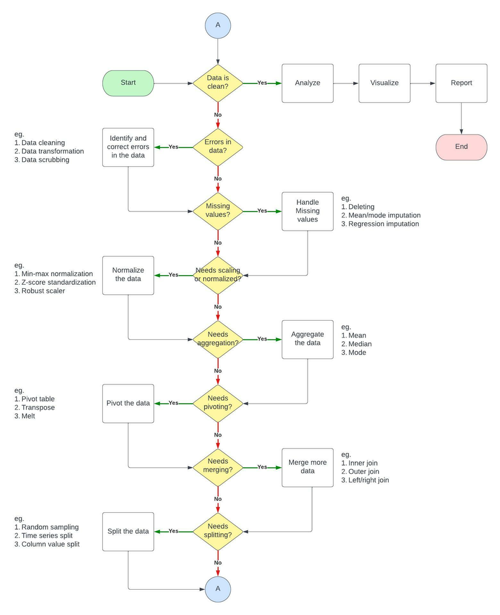

#### b) Choose a relevant encoding technique to transform the categorical data to numeric format.

Ordinal encoding: This involves assigning a unique integer value to each month or day. For example, we could assign 1 to January, 2 to February, and so on. This is useful if there is an inherent order to the months or days, such as when they are represented by numbers (e.g. 1 for January, 2 for February, etc.).

Ordinal encoding is a way to encode categorical variables when there is an inherent order or ranking to the categories. An example of this would be months of the year, where January comes before February and so on. Similarly, the days of the week have an inherent order, with Monday coming before Tuesday and so on. By ordinal encoding these variables, we can preserve the ranking or order of the categories. This can be useful in certain machine learning models, particularly decision trees, where the order of the categories can be used to make decisions.

For example, if we are trying to predict the weather, we might use the month as a feature. If we ordinal encode the month feature, the model can use the ranking of the months (e.g., January is first, February is second) to make predictions about the weather. If we one-hot encode the month feature, the model would not have any way to use the ranking of the months to make predictions.

Here is the demonstration of ordinal encoding of the month and day variables

```r
forest_fire_months <- df_forest_fire$month

unique(forest_fire_months)
```

```
 [1] "mar" "oct" "aug" "sep" "apr" "jun" "jul" "feb" "jan" "dec" "may" "nov"
```

```r
# Create an new dataframe with ordinal values to match with forest fire dataframe
months <- c("jan", "feb", "mar", "apr", "may", "jun", "jul", "aug", "sep", "oct", "nov", "dec")

months_ordinal_values <- 1:length(months)

df_months_ordinal <- data.frame(month = months, ordinal = months_ordinal_values)

df_months_ordinal
```

| month | ordinal |
| --- | --- |
| jan | 1 |
| feb | 2 |
| mar | 3 |
| apr | 4 |
| may | 5 |
| jun | 6 |
| jul | 7 |
| aug | 8 |
| sep | 9 |
| oct | 10 |

[output cut: 2 more lines]

Matching forest fire months to ordinal values to the newly created dataset

```r
forest_fire_months_ordinal <- match(forest_fire_months, df_months_ordinal$month)

forest_fire_months_ordinal
```

```
  [1]  3 10 10  3  3  8  8  8  9  9  9  9  8  9  9  9  3 10  3  4  9  9  6  8  8  8  9  9  9  9  9  9  9  9  9  9 10 10 10  3  7  8  8  9  9  9  9  7  3  3  9  8  8  8  8  9  9 10  2  2  3  3  8  8  8  8  9  9
 [69]  9  3  3  9  3  8  9  2  2  3  8  8  8  8  8  8  8  9  9  9  9  3  8  3  8  8  8  9  2  3  8  8  8  8  8  9  1  3  3  8  9  9  3  3  9  9  3  3  3  3  3  8  8  8  9  9  9 10  3  9 10 10  2  3  3  9  3  8
[137]  9  9  7  9  9  8  8  7  8  8  3  9  8  9  6  7  7  9  9  8  9  8  8  9  3  8  3  9  9  3  8  8  3  8  9  8  8  9  8  8  4  8  9  8  9 10  2 10  8  9  3  9  3  3  3  8  8  9  8  8  4  9  9  9  9  3  2 10
[205]  3  9  8  9  9  9 10  8  9  3  3  3  9  9  9  3  8  9  3  7  9  9 10  8  9  8  9  9  9  9  9  8  9  9  9  4  4  4  8  8  8  8  8  8  8  8  8  8  8  8  8  8  8  8  8  8  8  8  8  8  8  8  8  8  8  8  8  8
[273]  8 12 12 12 12 12 12 12 12 12  2  2  2  7  7  7  7  7  7  7  7  7  7  6  6  6  6  6  6  6  6  6  5  9  9  9  9  9  9  9  9  9  9  9  9  9  9  9  9  9  9  9  9  9  9  9  9  9  9  9  9  9  9  9  9  9  9  9
[341]  9  9  9  9  9  9  9  9  9  9  9  9  9  9  9  9  9  9  9  9  9  9  9  9  9  9  9  9  9  9  9  7  8  8  9  9  8  8  3  1  7  8  8  8  8  8  9  3  8  8  2  9  9  3  2  2  9  8  8  6  6  9  8  8  9  8  9  2
[409]  9  7  2  2  7  8  8  8  7  3  8  8  8  8  7  9  8  8  8  8  8  8  9  8  8  8  8  7  8  8  8  9  9  8  4  7  9  8  8  3  9  8  8  8  8  8  8  7  8  8  8  8  8  8  9  2  2  2  3  3  3  4  4  5  6  6  6  6
[477]  7  7  7  7  7  7  8  8  8  8  8  8  8  8  8  8  8  8  8  8  8  8  8  8  8  8  8  8  8  8  8  8  8  8  8  8  8  8  8  8 11
```

Merge ordinals to forest fire dataset

```r
df_forest_fire$month_ordinal <- forest_fire_months_ordinal

df_forest_fire
```

| X | Y | month | day | FFMC | DMC | DC | ISI | temp | RH | wind | rain | area | month_ordinal |
| --- | --- | --- | --- | --- | --- | --- | --- | --- | --- | --- | --- | --- | --- |
| 7 | 5 | mar | fri | 86.2 | 26.2 | 94.3 | 5.1 | 8.2 | 51 | 6.7 | 0.0 | 0.00 | 3 |
| 7 | 4 | oct | tue | 90.6 | 35.4 | 669.1 | 6.7 | 18.0 | 33 | 0.9 | 0.0 | 0.00 | 10 |
| 7 | 4 | oct | sat | 90.6 | 43.7 | 686.9 | 6.7 | 14.6 | 33 | 1.3 | 0.0 | 0.00 | 10 |
| 8 | 6 | mar | fri | 91.7 | 33.3 | 77.5 | 9.0 | 8.3 | 97 | 4.0 | 0.2 | 0.00 | 3 |
| 8 | 6 | mar | sun | 89.3 | 51.3 | 102.2 | 9.6 | 11.4 | 99 | 1.8 | 0.0 | 0.00 | 3 |
| 8 | 6 | aug | sun | 92.3 | 85.3 | 488.0 | 14.7 | 22.2 | 29 | 5.4 | 0.0 | 0.00 | 8 |
| 8 | 6 | aug | mon | 92.3 | 88.9 | 495.6 | 8.5 | 24.1 | 27 | 3.1 | 0.0 | 0.00 | 8 |
| 8 | 6 | aug | mon | 91.5 | 145.4 | 608.2 | 10.7 | 8.0 | 86 | 2.2 | 0.0 | 0.00 | 8 |
| 8 | 6 | sep | tue | 91.0 | 129.5 | 692.6 | 7.0 | 13.1 | 63 | 5.4 | 0.0 | 0.00 | 9 |
| 7 | 5 | sep | sat | 92.5 | 88.0 | 698.6 | 7.1 | 22.8 | 40 | 4.0 | 0.0 | 0.00 | 9 |

[output cut: 507 more lines]

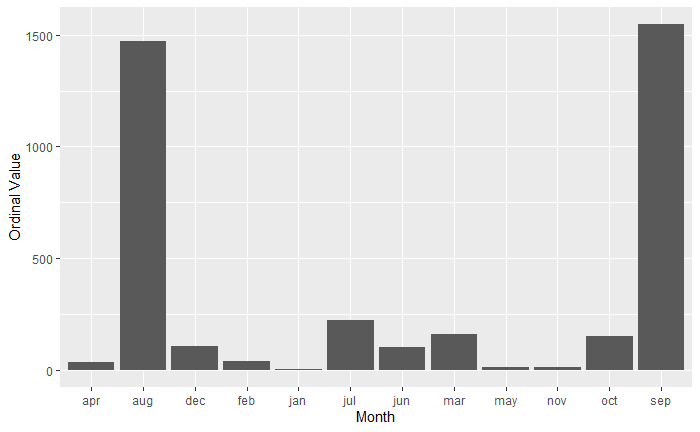

```r
# install.packages('ggplot2')
library(ggplot2)

ggplot(df_forest_fire, aes(x = month, y = month_ordinal)) +
  geom_col() +
  labs(x = "Month", y = "Ordinal Value")
```

```r
forest_fire_days <- df_forest_fire$day

unique(forest_fire_days)
```

```
[1] "fri" "tue" "sat" "sun" "mon" "wed" "thu"
```

```r
# Create an new dataframe with ordinal values to match with forest fire dataframe
days <- c("mon", "tue", "wed", "thu", "fri", "sat", "sun")

days_ordinal_values <- 1:length(days)

df_days_ordinal <- data.frame(day = days, ordinal = days_ordinal_values)

df_days_ordinal
```

| day | ordinal |
| --- | --- |
| mon | 1 |
| tue | 2 |
| wed | 3 |
| thu | 4 |
| fri | 5 |
| sat | 6 |
| sun | 7 |

Matching forest fire days to ordinal values to the newly created dataset

```r
forest_fire_days_ordinal <- match(forest_fire_days, df_days_ordinal$day)

forest_fire_days_ordinal
```

```
  [1] 5 2 6 5 7 7 1 1 2 6 6 6 5 1 3 5 6 1 3 6 2 1 7 6 6 7 5 1 6 7 5 1 5 7 1 2 2 5 6 2 2 6 2 6 3 3 1 1 1 1 4 7 3 3 4 4 2 7 1 5 7 7 4 7 1 4 5 5 5 5 5 5 5 2 5 4 5 1 5 2 7 7 2 3 4 4 4 4 7 6 6 5 7 7 1 7 6 6 7 7 7 2
[103] 2 6 6 5 4 7 6 1 5 5 7 1 2 2 6 6 1 4 1 1 7 2 5 7 1 5 3 7 6 1 7 4 2 6 7 1 2 2 1 3 5 6 3 4 1 2 2 4 5 7 6 5 6 7 6 3 3 5 1 4 6 6 7 4 3 3 5 4 3 3 7 1 6 6 4 7 3 2 7 1 7 1 5 2 7 1 6 7 5 4 2 3 2 5 4 4 2 1 2 7 7 3
[205] 6 4 6 2 5 4 6 6 5 1 6 6 7 1 3 1 7 5 1 5 3 7 1 6 7 6 3 7 2 2 6 7 6 2 6 7 3 5 7 7 7 7 7 3 3 3 3 3 3 4 4 4 6 6 6 6 1 5 5 5 5 2 2 2 2 2 2 2 2 7 3 4 1 1 1 1 5 2 7 3 5 7 3 6 6 6 6 6 5 2 2 7 7 7 3 6 1 1 5 5 6 7
[307] 7 7 7 7 7 7 7 3 3 3 4 4 4 4 4 4 4 4 4 6 6 6 6 6 6 6 6 1 1 1 1 1 1 1 1 1 1 1 1 1 1 5 5 5 5 5 5 5 5 5 5 5 5 5 5 5 5 2 2 2 2 2 6 7 7 3 7 4 5 6 1 6 4 7 3 4 3 4 6 7 7 4 5 5 1 5 7 2 1 7 7 7 6 3 3 4 5 4 3 2 6 6
[409] 5 2 5 5 1 6 7 4 2 3 7 7 3 3 7 6 6 4 4 1 4 7 4 6 4 7 5 6 1 6 6 5 5 1 1 5 5 7 7 3 3 7 3 5 1 4 4 1 4 3 6 6 6 6 7 2 2 6 1 3 4 7 7 5 1 6 4 4 4 7 7 1 4 4 7 7 7 1 2 2 2 3 3 4 5 5 6 1 1 2 2 2 2 2 2 3 3 4 5 5 5 5
[511] 5 7 7 7 7 6 2
```

Merge ordinals to forest fire dataset

```r
df_forest_fire$day_ordinal <- forest_fire_days_ordinal

df_forest_fire
```

| X | Y | month | day | FFMC | DMC | DC | ISI | temp | RH | wind | rain | area | month_ordinal | day_ordinal |
| --- | --- | --- | --- | --- | --- | --- | --- | --- | --- | --- | --- | --- | --- | --- |
| 7 | 5 | mar | fri | 86.2 | 26.2 | 94.3 | 5.1 | 8.2 | 51 | 6.7 | 0.0 | 0.00 | 3 | 5 |
| 7 | 4 | oct | tue | 90.6 | 35.4 | 669.1 | 6.7 | 18.0 | 33 | 0.9 | 0.0 | 0.00 | 10 | 2 |
| 7 | 4 | oct | sat | 90.6 | 43.7 | 686.9 | 6.7 | 14.6 | 33 | 1.3 | 0.0 | 0.00 | 10 | 6 |
| 8 | 6 | mar | fri | 91.7 | 33.3 | 77.5 | 9.0 | 8.3 | 97 | 4.0 | 0.2 | 0.00 | 3 | 5 |
| 8 | 6 | mar | sun | 89.3 | 51.3 | 102.2 | 9.6 | 11.4 | 99 | 1.8 | 0.0 | 0.00 | 3 | 7 |
| 8 | 6 | aug | sun | 92.3 | 85.3 | 488.0 | 14.7 | 22.2 | 29 | 5.4 | 0.0 | 0.00 | 8 | 7 |
| 8 | 6 | aug | mon | 92.3 | 88.9 | 495.6 | 8.5 | 24.1 | 27 | 3.1 | 0.0 | 0.00 | 8 | 1 |
| 8 | 6 | aug | mon | 91.5 | 145.4 | 608.2 | 10.7 | 8.0 | 86 | 2.2 | 0.0 | 0.00 | 8 | 1 |
| 8 | 6 | sep | tue | 91.0 | 129.5 | 692.6 | 7.0 | 13.1 | 63 | 5.4 | 0.0 | 0.00 | 9 | 2 |
| 7 | 5 | sep | sat | 92.5 | 88.0 | 698.6 | 7.1 | 22.8 | 40 | 4.0 | 0.0 | 0.00 | 9 | 6 |

[output cut: 507 more lines]

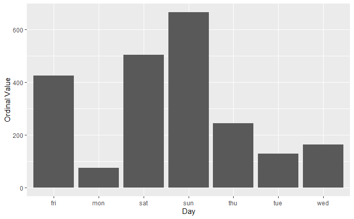

```r
ggplot(df_forest_fire, aes(x = day, y = day_ordinal)) +
  geom_col() +
  labs(x = "Day", y = "Ordinal Value")
```

#### c) Formulate the questions for EDA (Exploratory Data Analysis) and perform EDA based on the data provided and address the issues to understand the impact of fire and the resulting burned area.

```r
summary(df_forest_fire)
```

```
       X               Y          month               day                 FFMC            DMC              DC             ISI              temp             RH              wind            rain
 Min.   :1.000   Min.   :2.0   Length:517         Length:517         Min.   :18.70   Min.   :  1.1   Min.   :  7.9   Min.   : 0.000   Min.   : 2.20   Min.   : 15.00   Min.   :0.400   Min.   :0.00000
 1st Qu.:3.000   1st Qu.:4.0   Class :character   Class :character   1st Qu.:90.20   1st Qu.: 68.6   1st Qu.:437.7   1st Qu.: 6.500   1st Qu.:15.50   1st Qu.: 33.00   1st Qu.:2.700   1st Qu.:0.00000
 Median :4.000   Median :4.0   Mode  :character   Mode  :character   Median :91.60   Median :108.3   Median :664.2   Median : 8.400   Median :19.30   Median : 42.00   Median :4.000   Median :0.00000
 Mean   :4.669   Mean   :4.3                                         Mean   :90.64   Mean   :110.9   Mean   :547.9   Mean   : 9.022   Mean   :18.89   Mean   : 44.29   Mean   :4.018   Mean   :0.02166
 3rd Qu.:7.000   3rd Qu.:5.0                                         3rd Qu.:92.90   3rd Qu.:142.4   3rd Qu.:713.9   3rd Qu.:10.800   3rd Qu.:22.80   3rd Qu.: 53.00   3rd Qu.:4.900   3rd Qu.:0.00000
 Max.   :9.000   Max.   :9.0                                         Max.   :96.20   Max.   :291.3   Max.   :860.6   Max.   :56.100   Max.   :33.30   Max.   :100.00   Max.   :9.400   Max.   :6.40000
      area         month_ordinal     day_ordinal
 Min.   :   0.00   Min.   : 1.000   Min.   :1.000
 1st Qu.:   0.00   1st Qu.: 7.000   1st Qu.:2.000
 Median :   0.52   Median : 8.000   Median :5.000
 Mean   :  12.85   Mean   : 7.476   Mean   :4.259
 3rd Qu.:   6.57   3rd Qu.: 9.000   3rd Qu.:6.000
 Max.   :1090.84   Max.   :12.000   Max.   :7.000
```

2. How are the features related to one another?
- Using scatter plots to visualize the relationships between pairs of features. we can also use correlation coefficients, such as Pearson’s r, to quantify the strength and direction of the relationships.

```r
# select numerical values from the dataframe
df_num_forest_fire <- df_forest_fire[c(1, 2, 5, 6, 7, 8, 9, 10, 11, 12, 13)]

cor_matrix_forest_fire <- cor(df_num_forest_fire)

cor_matrix_forest_fire
```

```
                X            Y        FFMC          DMC          DC          ISI        temp          RH        wind         rain         area
X     1.000000000  0.539548171 -0.02103927 -0.048384178 -0.08591612  0.006209941 -0.05125826  0.08522319  0.01879782  0.065387168  0.063385299
Y     0.539548171  1.000000000 -0.04630755  0.007781561 -0.10117777 -0.024487992 -0.02410308  0.06222073 -0.02034085  0.033234103  0.044873225
FFMC -0.021039272 -0.046307546  1.00000000  0.382618800  0.33051180  0.531804931  0.43153226 -0.30099542 -0.02848481  0.056701533  0.040122004
DMC  -0.048384178  0.007781561  0.38261880  1.000000000  0.68219161  0.305127835  0.46959384  0.07379494 -0.10534225  0.074789982  0.072994296
DC   -0.085916123 -0.101177767  0.33051180  0.682191612  1.00000000  0.229154169  0.49620805 -0.03919165 -0.20346569  0.035860862  0.049383225
ISI   0.006209941 -0.024487992  0.53180493  0.305127835  0.22915417  1.000000000  0.39428710 -0.13251718  0.10682589  0.067668190  0.008257688
temp -0.051258262 -0.024103084  0.43153226  0.469593844  0.49620805  0.394287104  1.00000000 -0.52739034 -0.22711622  0.069490547  0.097844107
RH    0.085223194  0.062220731 -0.30099542  0.073794941 -0.03919165 -0.132517177 -0.52739034  1.00000000  0.06941007  0.099751223 -0.075518563
wind  0.018797818 -0.020340852 -0.02848481 -0.105342253 -0.20346569  0.106825888 -0.22711622  0.06941007  1.00000000  0.061118880  0.012317277
rain  0.065387168  0.033234103  0.05670153  0.074789982  0.03586086  0.067668190  0.06949055  0.09975122  0.06111888  1.000000000 -0.007365729
area  0.063385299  0.044873225  0.04012200  0.072994296  0.04938323  0.008257688  0.09784411 -0.07551856  0.01231728 -0.007365729  1.000000000
```

Melt the correlation matrix

```r
library(reshape2)
df_cor_matrix_forest_fire <- subset(melt(cor_matrix_forest_fire))

df_cor_matrix_forest_fire
```

|  | Var1 | Var2 | value |
| --- | --- | --- | --- |
| 1 | X | X | 1.000000000 |
| 2 | Y | X | 0.539548171 |
| 3 | FFMC | X | -0.021039272 |
| 4 | DMC | X | -0.048384178 |
| 5 | DC | X | -0.085916123 |
| 6 | ISI | X | 0.006209941 |
| 7 | temp | X | -0.051258262 |
| 8 | RH | X | 0.085223194 |
| 9 | wind | X | 0.018797818 |
| 10 | rain | X | 0.065387168 |

[output cut: 111 more lines]

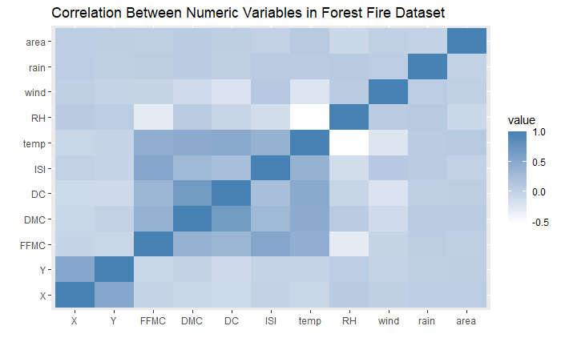

```r
# install.packages('reshape2')
library(reshape2)

ggplot(df_cor_matrix_forest_fire, aes(x = Var1, y = Var2, fill = value)) +
  geom_tile() +
  scale_fill_gradient(low = "white", high = "steelblue") +
  labs(x = '', y = '') +
  ggtitle('Correlation Between Numeric Variables in Forest Fire Dataset')
```

Find the pairs with moderate to strong negative correlation (-0.3 to -0.999)

```r
# install.packages('dplyr')
library(dplyr)
negative_correlation <- df_cor_matrix_forest_fire[(df_cor_matrix_forest_fire$value <= -0.3) & (df_cor_matrix_forest_fire$value >= -0.999), ]

negative_correlation_unique <- negative_correlation %>% distinct(value, .keep_all = TRUE)

negative_correlation_unique[order(negative_correlation_unique$value),]
```

|  | Var1 | Var2 | value |
| --- | --- | --- | --- |
| 2 | RH | temp | -0.5273903 |
| 1 | RH | FFMC | -0.3009954 |

Find the pairs with moderate to strong positive correlation (0.3 to 0.999)

```r
positive_correlation <- df_cor_matrix_forest_fire[(df_cor_matrix_forest_fire$value >= 0.3) & (df_cor_matrix_forest_fire$value <= 0.999), ]

positive_correlation_unique <- positive_correlation %>% distinct(value, .keep_all = TRUE)

positive_correlation_unique[order(-positive_correlation_unique$value),]
```

|  | Var1 | Var2 | value |
| --- | --- | --- | --- |
| 6 | DC | DMC | 0.6821916 |
| 1 | Y | X | 0.5395482 |
| 4 | ISI | FFMC | 0.5318049 |
| 9 | temp | DC | 0.4962081 |
| 8 | temp | DMC | 0.4695938 |
| 5 | temp | FFMC | 0.4315323 |
| 10 | temp | ISI | 0.3942871 |
| 2 | DMC | FFMC | 0.3826188 |
| 3 | DC | FFMC | 0.3305118 |
| 7 | ISI | DMC | 0.3051278 |

3. Are there any missing values in the dataset, and how are they distributed?
- Using the is.na function in R to identify missing values, and we can use summary statistics and visualizations to understand how they are distributed.

```r
forest_fire_na_counts <- colSums(is.na(df_forest_fire[1:13]))

forest_fire_na_counts
```

```
    X     Y month   day  FFMC   DMC    DC   ISI  temp    RH  wind  rain  area
    0     0     0     0     0     0     0     0     0     0     0     0     0
```

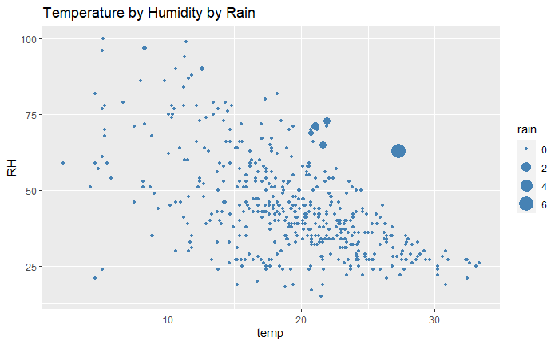

```r
ggplot(df_forest_fire, aes(x = temp, y = RH, size = rain)) +
  geom_point(colour = 'steelblue') +
  ggtitle('Temperature by Humidity by Rain')
```

#### d) Analyse the benefits and drawbacks for feature selection and extraction techniques. Which features are important from the provided dataset? (Feature Selection Method)

There are several benefits and drawbacks to feature selection and extraction techniques:

Benefits:

1. Reduce the complexity of the model and improve the model’s interpretability.
2. Improve the generalization ability of the model.
3. Speed up the training process.
4. Reduce the risk of overfitting.

Drawbacks:

1. May discard useful information and decrease the performance of the model.
2. Can be time-consuming to evaluate different feature subsets.

#### e) Prepare the data for the machine learning model after encoding and feature selection, predict the burned area of forest fires using the machine learning model.

Multiple linear regression is a type of regression analysis in which there are multiple independent variables (also known as explanatory variables) predicting a dependent variable. It is used to model the relationship between the independent variables and the dependent variable, and to predict the value of the dependent variable based on the values of the independent variables.

In multiple linear regression, the relationship between the independent variables and the dependent variable is modeled using a linear equation of the form:

y = b0 + b1x1 + b2x2 + … + bn*xn

where y is the dependent variable, x1, x2, …, xn are the independent variables, and b0, b1, b2, …, bn are the coefficients (also known as weights) that determine the strength and direction of the relationship between each independent variable and the dependent variable.

```r
# install.packages('caTools')
library(caTools)

split <- sample.split(
  Y = df_forest_fire$area,
  SplitRatio = 0.8
)

training_set <- subset(df_forest_fire, split == TRUE)

# create a subset excluding the month and day attributes as they have been encoded
training_set <- training_set[, c(1,2, 5:15)]

test_set <- subset(df_forest_fire, split == FALSE)

# create a subset excluding the month and day attributes as they have been encoded
test_set <- test_set[, c(1,2, 5:15)]
```

```r
training_set
```

|  | X | Y | FFMC | DMC | DC | ISI | temp | RH | wind | rain | area | month_ordinal | day_ordinal |
| --- | --- | --- | --- | --- | --- | --- | --- | --- | --- | --- | --- | --- | --- |
| 2 | 7 | 4 | 90.6 | 35.4 | 669.1 | 6.7 | 18.0 | 33 | 0.9 | 0.0 | 0.00 | 10 | 2 |
| 3 | 7 | 4 | 90.6 | 43.7 | 686.9 | 6.7 | 14.6 | 33 | 1.3 | 0.0 | 0.00 | 10 | 6 |
| 4 | 8 | 6 | 91.7 | 33.3 | 77.5 | 9.0 | 8.3 | 97 | 4.0 | 0.2 | 0.00 | 3 | 5 |
| 5 | 8 | 6 | 89.3 | 51.3 | 102.2 | 9.6 | 11.4 | 99 | 1.8 | 0.0 | 0.00 | 3 | 7 |
| 6 | 8 | 6 | 92.3 | 85.3 | 488.0 | 14.7 | 22.2 | 29 | 5.4 | 0.0 | 0.00 | 8 | 7 |
| 7 | 8 | 6 | 92.3 | 88.9 | 495.6 | 8.5 | 24.1 | 27 | 3.1 | 0.0 | 0.00 | 8 | 1 |
| 8 | 8 | 6 | 91.5 | 145.4 | 608.2 | 10.7 | 8.0 | 86 | 2.2 | 0.0 | 0.00 | 8 | 1 |
| 9 | 8 | 6 | 91.0 | 129.5 | 692.6 | 7.0 | 13.1 | 63 | 5.4 | 0.0 | 0.00 | 9 | 2 |
| 10 | 7 | 5 | 92.5 | 88.0 | 698.6 | 7.1 | 22.8 | 40 | 4.0 | 0.0 | 0.00 | 9 | 6 |
| 11 | 7 | 5 | 92.5 | 88.0 | 698.6 | 7.1 | 17.8 | 51 | 7.2 | 0.0 | 0.00 | 9 | 6 |

[output cut: 457 more lines]

```r
test_set
```

|  | X | Y | FFMC | DMC | DC | ISI | temp | RH | wind | rain | area | month_ordinal | day_ordinal |
| --- | --- | --- | --- | --- | --- | --- | --- | --- | --- | --- | --- | --- | --- |
| 1 | 7 | 5 | 86.2 | 26.2 | 94.3 | 5.1 | 8.2 | 51 | 6.7 | 0.0 | 0.00 | 3 | 5 |
| 15 | 6 | 5 | 92.9 | 133.3 | 699.6 | 9.2 | 26.4 | 21 | 4.5 | 0.0 | 0.00 | 9 | 3 |
| 16 | 6 | 5 | 93.3 | 141.2 | 713.9 | 13.9 | 22.9 | 44 | 5.4 | 0.0 | 0.00 | 9 | 5 |
| 19 | 6 | 4 | 89.2 | 27.9 | 70.8 | 6.3 | 15.9 | 35 | 4.0 | 0.0 | 0.00 | 3 | 3 |
| 23 | 7 | 4 | 94.3 | 96.3 | 200.0 | 56.1 | 21.0 | 44 | 4.5 | 0.0 | 0.00 | 6 | 7 |
| 25 | 7 | 4 | 93.5 | 139.4 | 594.2 | 20.3 | 23.7 | 32 | 5.8 | 0.0 | 0.00 | 8 | 6 |
| 28 | 7 | 4 | 90.9 | 126.5 | 686.5 | 7.0 | 19.4 | 48 | 1.3 | 0.0 | 0.00 | 9 | 1 |
| 31 | 6 | 3 | 94.3 | 85.1 | 692.3 | 15.9 | 25.4 | 24 | 3.6 | 0.0 | 0.00 | 9 | 5 |
| 35 | 6 | 3 | 91.8 | 78.5 | 724.3 | 9.2 | 21.2 | 32 | 2.7 | 0.0 | 0.00 | 9 | 1 |
| 47 | 5 | 6 | 90.9 | 126.5 | 686.5 | 7.0 | 14.7 | 70 | 3.6 | 0.0 | 0.00 | 9 | 1 |

[output cut: 40 more lines]

Fit multile linear regression into the training set

```r
regressor <- lm(
  formula = area ~ .,
  data = training_set
)

summary(regressor)
```

```
Call:
lm(formula = area ~ ., data = training_set)

Residuals:
    Min      1Q  Median      3Q     Max
 -41.60  -17.33   -8.54    0.19 1060.87

Coefficients:
               Estimate Std. Error t value Pr(>|t|)
(Intercept)   -13.57827   70.24925  -0.193    0.847
X               2.16435    1.59899   1.354    0.177
Y               0.21721    3.04639   0.071    0.943
FFMC           -0.06572    0.73781  -0.089    0.929
DMC             0.10966    0.07648   1.434    0.152
DC             -0.03188    0.03463  -0.920    0.358
ISI            -0.77782    1.01908  -0.763    0.446
temp            0.93294    0.87107   1.071    0.285
RH             -0.24817    0.26305  -0.943    0.346
wind            1.44904    1.89202   0.766    0.444
rain           -2.67934   10.35066  -0.259    0.796
month_ordinal   2.62791    3.00840   0.874    0.383
day_ordinal     0.71649    1.53251   0.468    0.640

Residual standard error: 66.82 on 454 degrees of freedom
Multiple R-squared:  0.02626,   Adjusted R-squared:  0.0005187
F-statistic:  1.02 on 12 and 454 DF,  p-value: 0.4288
```

Using Backward eliminatio method to select a subset of the variables to include in a multiple linear regression model. The goal of backward elimination is to find the simplest model that is still able to explain the variance in the dependent variable.

First we start with a full model that includes all of the variables that we are interested in. Then, we iteratively remove the variables that are least statistically significant until only the significant variables remain.

To determine statistical significance, we can use a threshold such as p < 0.05, which means that there is less than a 5% chance that the relationship between the variable and the dependent variable occurred by chance.

After using backward elimination, and are left with only one variable that has statistical significance, it means that this is the only variable that is significantly related to the dependent variable. This may indicate that the other variables are not important for explaining the variance in the dependent variable, or it may indicate that the remaining variable is correlated with the other variables and is “absorbing” their effects.

```r
regressor <- lm(
  formula = area ~ temp ,
  data = training_set
)

summary(regressor)
```

```
Call:
lm(formula = area ~ temp, data = training_set)

Residuals:
    Min      1Q  Median      3Q     Max
 -29.81  -15.90  -11.21   -3.35 1069.46

Coefficients:
            Estimate Std. Error t value Pr(>|t|)
(Intercept)  -7.5890    10.3673  -0.732   0.4645
temp          1.1542     0.5239   2.203   0.0281 *
---
Signif. codes:  0 ‘***’ 0.001 ‘**’ 0.01 ‘*’ 0.05 ‘.’ 0.1 ‘ ’ 1

Residual standard error: 66.56 on 465 degrees of freedom
Multiple R-squared:  0.01033,   Adjusted R-squared:  0.008201
F-statistic: 4.853 on 1 and 465 DF,  p-value: 0.02809
```

Create a new set from test set without the area variable to test predictions

```r
new_set = select(test_set, -area)

new_set
```

|  | X | Y | FFMC | DMC | DC | ISI | temp | RH | wind | rain | month_ordinal | day_ordinal |
| --- | --- | --- | --- | --- | --- | --- | --- | --- | --- | --- | --- | --- |
| 1 | 7 | 5 | 86.2 | 26.2 | 94.3 | 5.1 | 8.2 | 51 | 6.7 | 0.0 | 3 | 5 |
| 15 | 6 | 5 | 92.9 | 133.3 | 699.6 | 9.2 | 26.4 | 21 | 4.5 | 0.0 | 9 | 3 |
| 16 | 6 | 5 | 93.3 | 141.2 | 713.9 | 13.9 | 22.9 | 44 | 5.4 | 0.0 | 9 | 5 |
| 19 | 6 | 4 | 89.2 | 27.9 | 70.8 | 6.3 | 15.9 | 35 | 4.0 | 0.0 | 3 | 3 |
| 23 | 7 | 4 | 94.3 | 96.3 | 200.0 | 56.1 | 21.0 | 44 | 4.5 | 0.0 | 6 | 7 |
| 25 | 7 | 4 | 93.5 | 139.4 | 594.2 | 20.3 | 23.7 | 32 | 5.8 | 0.0 | 8 | 6 |
| 28 | 7 | 4 | 90.9 | 126.5 | 686.5 | 7.0 | 19.4 | 48 | 1.3 | 0.0 | 9 | 1 |
| 31 | 6 | 3 | 94.3 | 85.1 | 692.3 | 15.9 | 25.4 | 24 | 3.6 | 0.0 | 9 | 5 |
| 35 | 6 | 3 | 91.8 | 78.5 | 724.3 | 9.2 | 21.2 | 32 | 2.7 | 0.0 | 9 | 1 |
| 47 | 5 | 6 | 90.9 | 126.5 | 686.5 | 7.0 | 14.7 | 70 | 3.6 | 0.0 | 9 | 1 |

[output cut: 40 more lines]

Predicting the results

```r
y_pred <- predict(
  regressor,
  newdata = new_set
)

y_pred
```

```
        1        15        16        19        23        25        28        31        35        47        52        55        58        62        73        87        93       106       107       111
 1.875089 22.880769 18.841215 10.762108 16.648315 19.764542 14.801662 21.726611 16.879146  9.377118 17.225394 12.724177  8.338375 -1.241138 10.415860 21.726611 16.417483  7.068801 13.416672  8.222960
      115       116       120       122       124       131       136       138       163       244       286       290       301       304       316       335       343       358       379       388
10.646692 10.300444 15.032493 12.147098 13.070424 10.185029 12.724177 10.415860  9.954197 17.687057 19.418295 20.457037 16.302067 14.570830 13.762919 13.185840 16.186651 10.762108  2.452168  5.799227
      390       404       422       454       462       471       482       496       501       503
19.302879 16.994562 27.959066 12.493345 14.224582 12.724177 27.266571 19.995374 17.340810 16.302067
```

Visualize training test results

[figure not shown]

```r
ggplot() +
  geom_point(
    aes(
      x = training_set$temp,
      y = training_set$area
    ),
    colour = 'red'
  ) +
  ylim(0, 30) +
  geom_line(
    aes(
      x = training_set$temp,
      predict(regressor, newdata = training_set)
    ),
    colour = 'blue'
  ) +
  ggtitle('Temperature vs Area (Test Set)') +
  xlab('Temperature') +
  ylab('Area')
```

Visualize actual test results

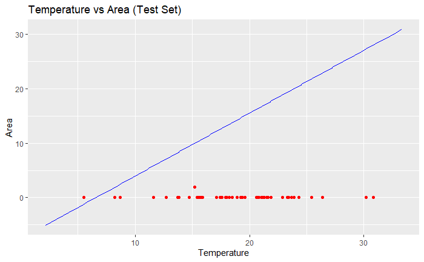

```r
ggplot() +
  geom_point(
    aes(
      x = test_set$temp,
      y = test_set$area
    ),
    colour = 'red'
  ) +
  geom_line(
    aes(
      x = training_set$temp,
      predict(regressor, newdata = training_set)
    ),
    colour = 'blue'
  ) +
  ggtitle('Temperature vs Area (Test Set)') +
  xlab('Temperature') +
  ylab('Area')
```

Visualize predicted test results

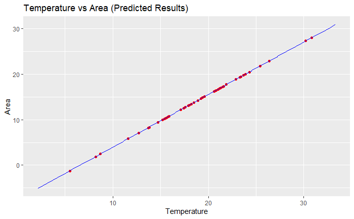

```r
ggplot() +
  geom_point(
    aes(
      x = test_set$temp,
      y = y_pred
    ),
    colour = 'red'
  ) +
  geom_line(
    aes(
      x = training_set$temp,
      predict(regressor, newdata = training_set)
    ),
    colour = 'blue'
  ) +
  ggtitle('Temperature vs Area (Predicted Results)') +
  xlab('Temperature') +
  ylab('Area')
```

#### f) we are free to perform any process to enhance an understanding of data preparation and exploration of the Forest data set.

Performed processes are provided in between tasks as demonstrations and visualizations.